# Greinasafn

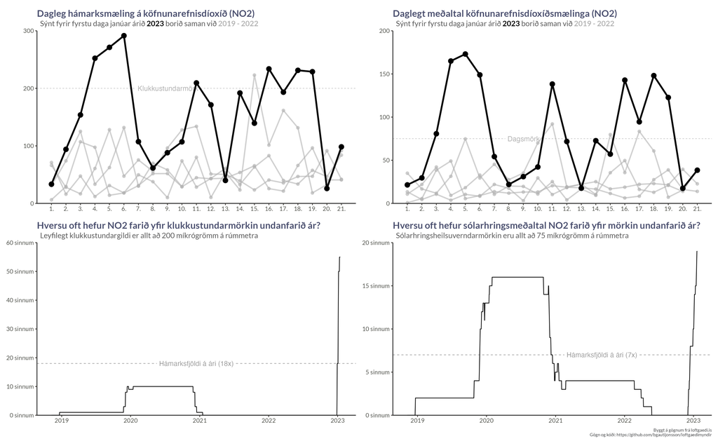

### Loftgæði

Samantekt á mælingum köfnunarefnisdíoxíðs (NO2) við Grensásveg

Nýlega var fjallað um óvenjulega háar mælingar á NO2 í Reykjavíkurborg. Hversu algeng eru slík tilvik? Hér ber ég mælingar ársins 2023 saman við fyrri ár.

Jan 21, 2023

Brynjólfur Gauti Guðrúnar Jónsson

[figure not shown]

### Vinnumarkaður

Hver er fjöldi starfandi einstaklinga og hvernig skiptast þeir á vinnumarkaði?

Reglulega sjást fyrirsagnir þar sem talað er um að opinbert starfsfólk sé allt of margt og að hlutfall þess af heildarfjölda vinnandi fólks sé of hátt. Hér kryf ég reglulega nýjustu gögnin til að geta vitað hvort slíkar fullyrðingar séu teknar úr samhengi eða endurspegli raunveruleikann.

Jan 17, 2023

Brynjólfur Gauti Guðrúnar Jónsson

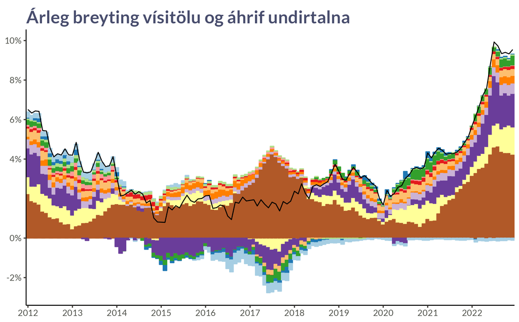

### Vísitala neysluverðs

Vísitalan og áhrif undirtalna á heildina unnið úr nýjustu gögnum Hagstofu hverju sinni

Verðbólga er ekki alltaf það sama og verðbólga. Stundum er stór hluti af henni hækkun á húsnæðisverði, stundum ferðir og flutningar. Það er því gott að skoða undirvísitölurnar og áhrif þeirra á heildina.

Dec 22, 2022

Brynjólfur Gauti Guðrúnar Jónsson

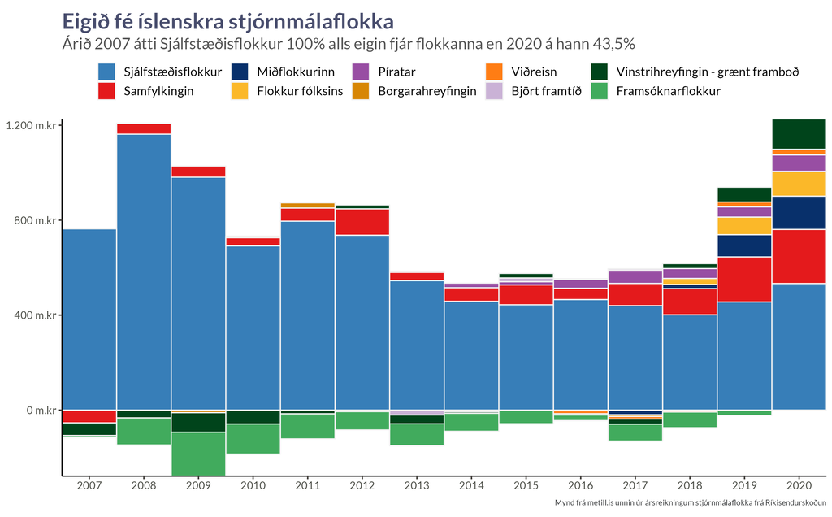

### Fjármál stjórnmálaflokkanna

Greining á ársreikningum stjórnmálaflokka úr gögnum Ríkisendurskoðunar

Hversu miklar tekjur hafa stjórnmálaflokkarnir og hvaðan koma þær? Hækka útgjöld þeirra sjáanlega í kringum kosningar og eiga þeir einhverjar eignir? Hér köfum við ofan í ársreikninga stjórnmálaflokkanna.

Oct 17, 2022

Brynjólfur Gauti Guðrúnar Jónsson

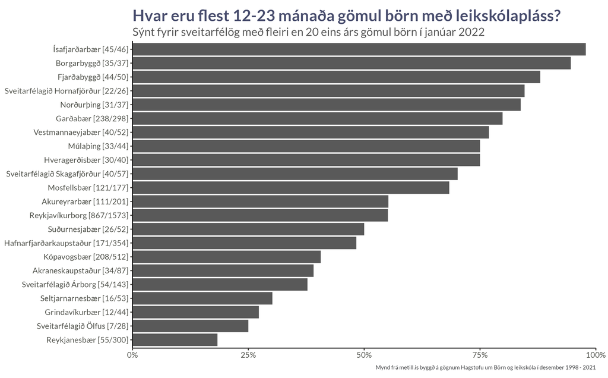

### Leikskólar

Hvernig gengur sveitarfélögum landsins að brúa bilið?

Hvernig gengur sveitarfélögum að útbúa leikskólapláss? Hvernig ber fjölda nemenda í leikskólum saman við heildarfjölda barna í hverjum árgangi? Hér skoðum við gögn Hagstofunnar um leikskóla og berum saman við mannfjöldatölur eftir aldri.

Oct 5, 2022

Brynjólfur Gauti Guðrúnar Jónsson

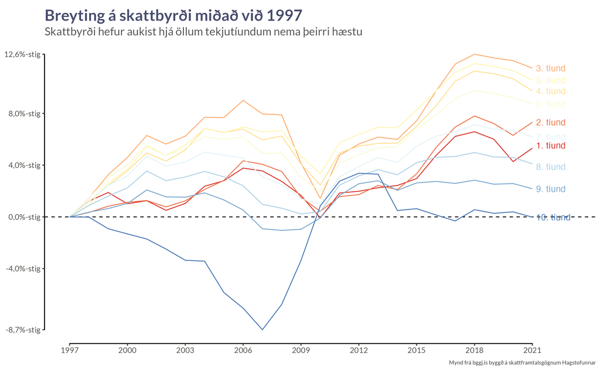

### Tekjur, skattar og kaupmáttur

Greining á tekjuskattsgögnum sem Hagstofan vinnur úr skattframtölum Íslendinga

Stundum les maður að skattakerfið ýti undir ójöfnuð, eða að það séu of háir skattar á þeim efnameiru. Hvort er það? Hér nota ég skattagögn Hagstofunnar til að skoða tekjur og skatta eftir tekjutíundum. Ég get ekki sagt hvort það sé sanngjarnt, en ég get sýnt hvernig það hefur breyst með tímanum.

Sep 11, 2022

Brynjólfur Gauti Guðrúnar Jónsson

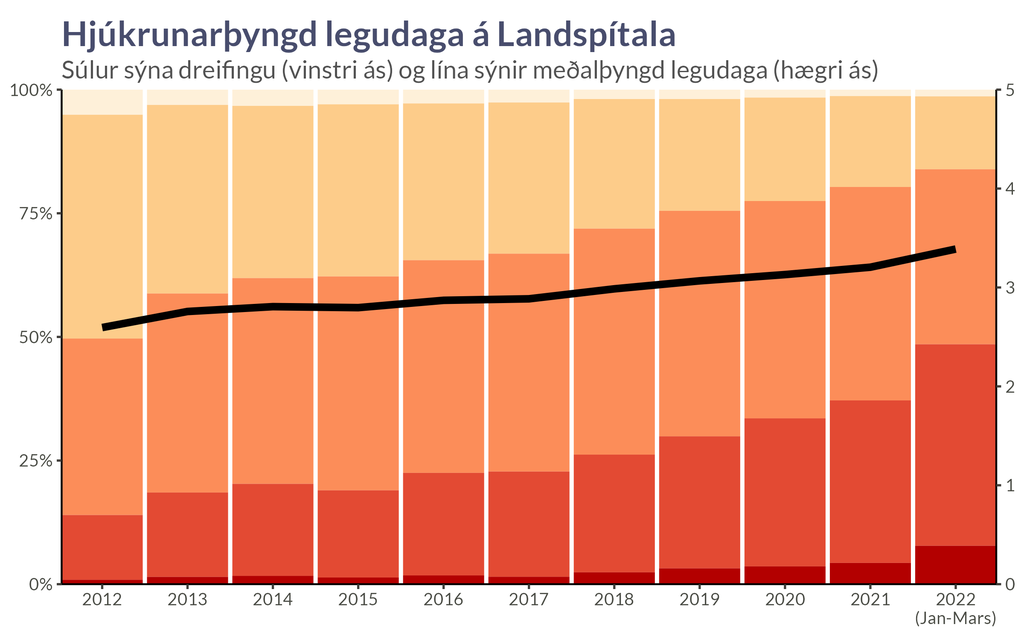

### Landspítalinn

Hvaða upplýsingar eru til um rekstur Landspítalans og hvar má finna þær?

Hvernig er nýting legurýma á Landspítala? Hvaða hlutfall launa fer í þessi margræddu millistjórnendastörf? Hér ætla ég aðeins að skoða hvaða gögn eru til um rekstur landspítalans, hvar má finna þau og hvað mætti betur fara í birtingu þeirra gagna.

Aug 24, 2022

Brynjólfur Gauti Guðrúnar Jónsson